# 時系列データ分析について

- 参考
  - [現場ですぐ使える時系列データ分析～データサイエンティストのための基礎知識](https://www.amazon.co.jp/dp/B00KNRL068/ref=cm_sw_em_r_mt_dp_FWCDFb1RJQY08)

# Chapter1 時系列データのリテラシー

- 時系列データとは
  - 対象のある側面を特定の時間間隔で観測した結果の集まり
- 時系列データとヒストグラム
  - 時系列データでヒストグラムを作ると、時間情報は無意味であるということになる
  - 理由  
    ヒストグラム:確率分布の形状を調べて、同一な確率分布から独立に抽出した標本か調べる  
    時系列データは抽出順＝時間情報を情報源とする
- 時系列データのモデル化
  1. 特定の時点の値が、過去の値に依存する分布
     - 自己回帰モデル（ARモデル）
  2. 日々分布が変化する（分散を時間依存の関数で表す）
     - 自己回帰条件付き分散不均一モデル（ARCHモデル）
     - GARCHモデル

# Chapter2 時系列データの観察と要約

## 2-1 時系列データを観察する

```r
library(dplyr)
library(ggplot2)
library(knitr)
opts_chunk$set(warning=FALSE, message=FALSE)
```

```r
exdata <- load("演習用データ/.Rdata")
price4 <- as.data.frame(price4)
price4 %>% head()
```

|  | x5202 | x7272 | x4927 | x4502 |
| --- | --- | --- | --- | --- |
| 1 | 55 | 682 | 2460 | 3595 |
| 2 | 56 | 672 | 2543 | 3575 |
| 3 | 56 | 668 | 2544 | 3570 |
| 4 | 57 | 674 | 2500 | 3500 |
| 5 | 60 | 711 | 2535 | 3545 |
| 6 | 62 | 726 | 2522 | 3550 |

```r
attach(price4)
```

#### 元データ（株価）を確認

```r
par(family = "HiraKakuProN-W3", mfcol=c(2, 2))
plot(x5202, type="l", main="旭硝子")
plot(x4927, type="l", main="ポーラHD")
```

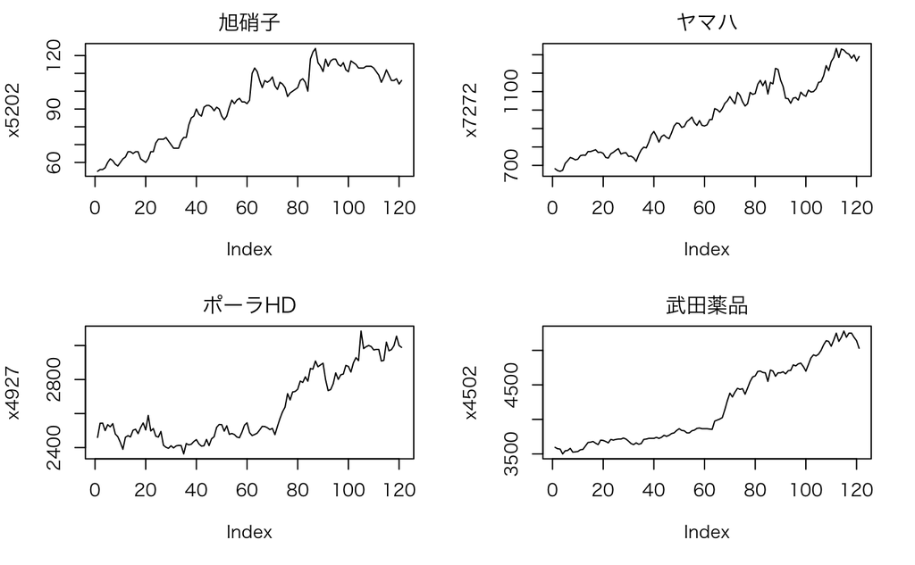

```r
plot(x7272, type="l", main="ヤマハ")
plot(x4502, type="l", main="武田薬品")
```

#### 投資開始時点の株価を1に揃える

```r
par(family = "HiraKakuProN-W3", mfcol=c(2, 2))
plot(x5202/x5202[1], type="l", main="旭硝子")
plot(x4927/x4927[1], type="l", main="ポーラHD")
```

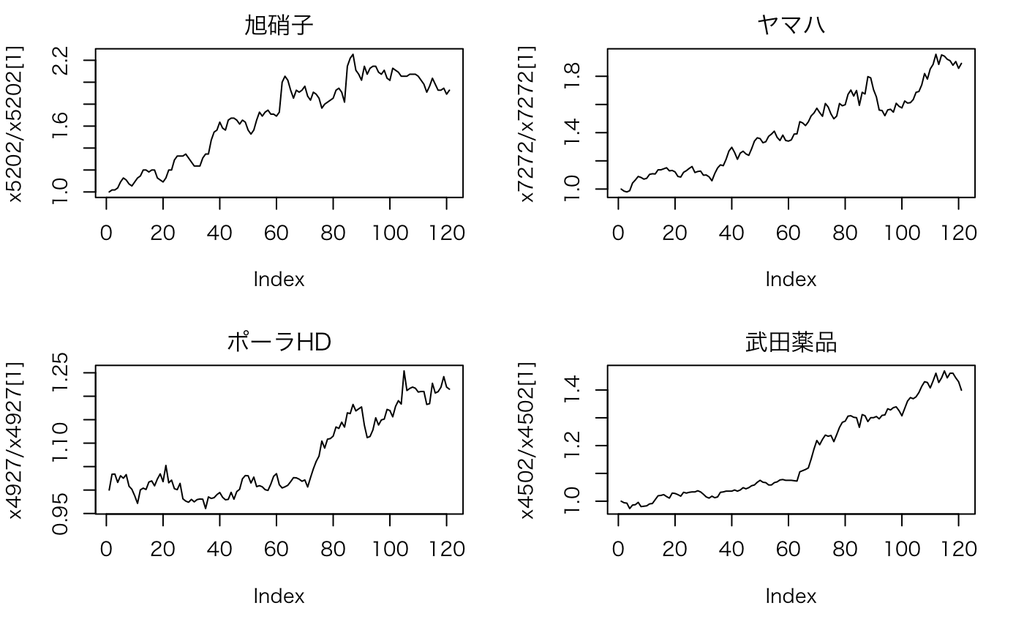

```r
plot(x7272/x7272[1], type="l", main="ヤマハ")
plot(x4502/x4502[1], type="l", main="武田薬品")
```